# Wprowadzenie do Uogólnionych Modeli Liniowych

Marcin Filip

23 March 2020

# Agenda

– Koncept modelu regresji

– Przypomnienie modelu regresji liniowej

– Uogólniony model liniowy

– Rodzina rozkładów wykładniczych

– Przykład

# Konept modelu regresji

Koncept modelu regresji opiera się o dwa stwierdzenia:

- dla każdej wartości zmiennej objaśniającej X, zmienna objaśniana Y jest zmienną losową o pewnej dystrybuancie;
- wartości oczekiwane zmiennych objaśnianych Y różnią się w zależności od wielkości zmiennej objaśniającej X w pewien systematyczny sposób.

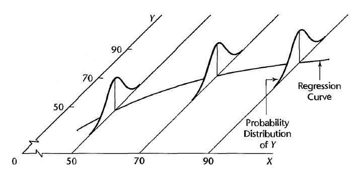

# Regresja liniowa - definicja 1/3

W modelu prostej regresji liniowej (Simple Linear Regression) zakładamy, że statystyczna zależność dwóch ciągłych zmiennych losowych X oraz Y jest przynajmniej w przybliżeniu liniowa:

$Y_i = \beta_0 + \beta_1X_i + \epsilon_i$, dla $i = 1, 2, ..., n$

gdzie $i$ oznaczają kolejne obserwacje, $Y_i$ są zmiennymi objaśnianymi (w $i$-tej obserwacji), $X_i$ reprezentują zmienne objaśniające, $\beta_0$ oraz $\beta_1$ są ustalonymi, ale nieznanymi stałymi - nazywane parametrami lub współczynnikami - które reprezentują przecięcie z osią współrzędnych oraz współczynnik kierunkowy prostej regresji liniowej, $\epsilon_i$ reprezentuje element losowy (szum), dla którego zakładamy, że $\epsilon_i$ są ${i.i.d.}$ z rozkładu o stałej wartości oczekiwanej $E[\epsilon] = 0$ oraz stałej wariancji $Var[\epsilon] = \sigma^2$.

Ponieważ $E[\epsilon] = 0$, to problem regresji liniowej jest w rzeczywistości problemem estymacji warunkowej wartości oczekiwanej:

$E[Y_i|X_i] = \beta_0 + \beta_1X_i$ oraz $Var[Y_i|X_i] = \sigma^2$, dla $i = 1, 2, ..., n$.

# Regresja liniowa - estymacja 2/3

**Estymator najmniejszych kwadratów**

W jaki sposób oszacować wartość parametrów? Najczęściej używaną metodą jest metoda najmiejszych kwadratów *(**LSE** - least squares estimator)*, która polega na minimalizowaniu sumy kwadratów reszt *(**RSS** - residual sum of squares)*:

$RSS(\beta_0, \beta_1) = \sum_{i=1}^{n}[Y_i-(\beta_0 + \beta_1X_i)]^2 = \sum_{i=0}^{n}(Y_i-\beta_0 - \beta_1X_i)^2$.

Twierdzenie Gaussa-Markowa mówi, że taki estymator $\beta_0$ oraz $\beta_1$ jest estymatorem nieobciążonym o najmniejszej wariancji wśród liniowych, nieobciążonych estymatorów liniowego modelu regresji.

Niewątpliwą zaletą tej procedury jest fakt, że nie wymaga ona założeń o rozkładzie zmiennej objaśnianej. Niestety to powoduje, że procedura może nam dostarczyć jedynie punktowe estymatory parametrów modelu $\beta_0$ oraz $\beta_1$. W celu uzyskania dodatkowych informacji np. o trafności modelu (przedziały ufności dla parametrów, aplikacja testów statystycznych) musimy poczynić dodatkowe założenie o rozkładzie zmiennej objaśnianej. W przypadu modelu regresji liniowej standardowym założeniem jest, że zmienna objaśniana ma rozkład normalny. Wprowadzenie założenie o konkretnej postaci rozkładu zmiennej objaśnianej otwiera nam furtkę do wykorzystania procedury estymacji największej wiarogodności.

# Regresja liniowa - estymacja 3/3

**Estymator największej wiarogodności**  
Intuicyjnie, procedura największej wiarogodności jako estymator wybiera takie wartości, które są najbardziej zgodne z danymi z próby, tj. takie wartości estymowanych parametrów, dla których prawdopodobieństwo otrzymania obserwacji z próby jest największe.

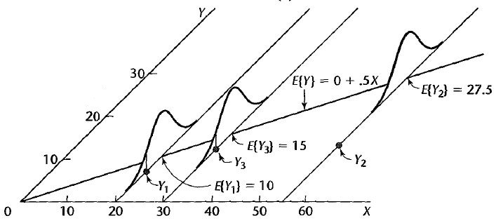

Sterujemy tak nachyleniem i wysokością prostej, tj. szukamy takich wielkości współczynników $\beta_0$ oraz $\beta_1$, żeby dla konkretnego zestawu danych funckja wiarogodności (rozumiana jako iloczyn wartości funkcji gęstości dla każdej wartości $Y_i$) była maksymalna.

Okazuje się, że estymator najmniejszych kwadratów parametrów $\beta_0$ oraz $\beta_1$ jest estymatorem największej wiarogodności.

# Regresja liniowa - podsumowanie

Podsumujmy teraz nasze dotychczasowe rozważania o modelu regresji liniowej w postaci trzech poniższych założeń:

**(LM1) Składnik losowy**:

$Y_i \stackrel{}{\sim} N(\mu_i, \sigma^2)$, dla $i = 1, 2, ..., n$.

*Odnosi się do rozkładu zmiennej objaśnianej $Y_i$*.

**(LM2): Składnik systematyczny**:

$\eta_i = \beta_0 + \beta_1X_i$, dla $i = 1, 2, ..., n$.

*Odnosi się do zmiennych objaśniających $X_i$ jako liniowa ich kombinacja (liniowy predyktor)*.

**(LM3): Funkcja łącząca**:

$\mu_i = \eta_i$, dla $i = 1, 2, ..., n$,

tj. $E[Y_i|X_i] = \beta_0 + \beta_1X_i$.

*Określa sposób połączenia składnika losowego i składnika systematycznego. Określa jak wartość oczekiwana zmiennej objaśnianej zależy od zmiennych objaśniających*.

# Regresja liniowa - ograniczenia

Model regresji liniowej nie będzie odpowiedni w następujących sytuacjach:

– trudno jest zapewnić ‘normalność’ i stałą wariancję zmiennej objaśnianej,  
– zbiór wartości zmiennej objaśnianej $Y$ ograniczony (np. $Y$ przyjmuje tylko dwie wartości, lub przyjmuje wartości całkowite dodatnie),

– addytywność efektów zmiennych narzucona przez połączenie założeń (LM2) oraz (LM3) nie oddaje rzeczywistości w wielu przypadkach. Np. modelowanie powierzchni skrzydeł motyla, gdzie zmiennymi objaśniającymi są długość i szerokość skrzydła.

# Uogólnione modele liniowe (GLM) 1/2

Możemy sobie w łatwy sposób poradzić z tymi ograniczeniami przechodząc do szerszej rodziny modeli regresji - uogólnionych modeli regresji liniowej. Pozostając w tej samej konwencji przedstawmy założenia GLM:

**(GLM1) Składnik losowy**:

$Y_i \stackrel{}{\sim} EF(\theta_i, \phi)$, dla $i = 1, 2, ..., n$,

gdzie $EF$ oznacza rozkład z rodziny rozkładów wykładniczych.

**(GLM2): Składnik systematyczny**:

$\eta_i = \beta_0 + \beta_1X_i$, dla $i = 1, 2, ..., n$.

**(GLM3): Funkcja łącząca**:

$g(\mu_i) = \eta_i$, dla $i = 1, 2, ..., n$,

tj. $g(E[Y_i|X_i]) = \beta_0 + \beta_1X_i$,

gdzie funkcja $g: {\rm I\!R} \mapsto {\rm I\!R}$ jest ściśle monotoniczna.

# Uogólnione modele liniowe (GLM) 2/2

Więcej o funkcji łączącej $g$:

- jako $g$ możemy przyjąć dowolną ściśle monotoniczną funkcję ${\rm I\!R} \mapsto {\rm I\!R}$, która będzie mapowała zbiór możliwych wartości $\mu_i$ ($\subseteq {\rm I\!R}$) na ${\rm I\!R}$ (zbiór wartości funkcji $\eta_i$).  
  Przykładowo, kiedy zmienna objaśniana $Y_i \stackrel{}{\sim} Bin(p_i)$, to funkcją $g$ może być dowolna ściśle monotoniczna funkcja $(0, 1) \mapsto {\rm I\!R}$. Kolokwialnie, funkcja $g$ ma powodować, że $\mu_i$ oraz $\eta_i$ będą kompatybilne.
- w przypadku regresji liniowej funkcja łącząca jest identycznością.
- oczywiście są pewne naturalne (kanoniczne) wybory funkcji łączacych, o których jest więcej na kolejnych slajdach, ale nie ma żadnych powodów *a priori*, dla których składnik systematyczny $\eta_i$ miałby być addytywny na skali zdefiniowanej przez tę naturalną funkcję łączacą.

# Rodzina rozkładów wykładniczych

Większość powszechnie używanych rozkładów, m.in. Normalny, Dwumianowy, Poissona, są rozkładami z rodziny rozkładów wykładniczych ($EF(\theta_i, \phi)$), których funkcja gęstości jest postaci:

$f(y_i; \theta_i, \phi) = exp\Big\{ \frac{y_i\theta_i-b(\theta_i)}{\phi}+c(y_i, \phi) \Big\}$,

określona dla wszystkich obserwacji zmiennej objasnianej $Y_i$, $i = 1, 2, ..., n$, gdzie $\theta_i$ to parametr **kanoniczny** (powiązany z wartością oczekiwaną), a $\phi$ to parametr dyspersji (powiązany z wariancją).

Dla praktycznych celów warto pamiętać, że rozkład z rodziny rozkładów wykładniczych ma dwie poniższe własności:  
– rozkład jest w pełni określony przez wartość oczekiwaną i wariancję (np. rozkład jednostajny nie jest),  
– wariancja $Y_i$ jest funkcją wartości oczekiwanej.

Można pokazać, że:

$\mu_i = E[Y_i] = b'(\theta_i)$ **(1)**

$Var[Y_i] = b''(\theta_i)\phi$.

Powyższą funkcję wiarogodności będziemy chcieli optymalizować po parametrach $\beta_0$ oraz $\beta_1$. Jak w takim razie te parametry powiązane są z parametrem $\theta_i$?

# Rodzina rozkładów wykładniczych

Z **(1)** oraz z **GLM3**:

$\theta_i \stackrel{(1)}{=} (b')^{-1}(\mu_i) \stackrel{GLM3}{=} (b')^{-1}(g^{-1}(\eta_i)) = (b')^{-1}(g^{-1}(\beta_0 + \beta_1X_i)).$

Funkcja $g$ jest **kanoniczną** funkcją łączącą jeżeli jest postaci:

$g = (b')^{-1},$

wtedy

$\theta_i = \eta_i = \beta_0 + \beta_1X_i.$

**Logarytm funkcja wiarogodności**

Ostatecznie logarytm funkcji wiarogodności, który będziemy opytmalizować jest postaci:

$l = \sum_{i=1}^{n}\Big\{ \frac{y_i(b')^{-1}(g^{-1}(\eta_i)) - b((b')^{-1}g^{-1}(\eta_i))}{\phi} + c(y_i, \phi) \Big\}$

jeśli $g$ jest kanoniczna (tj. $\theta_i = \eta_i$), to funkcja upraszcza się do:

$\sum_{i=1}^{n}\Big\{ \frac{y_i\eta_i - b(\eta_i)}{\phi} + c(y_i, \phi) \Big\}$,

gdzie $\eta_i = \beta_0 + \beta_1X_i.$

Pozostaje teraz zoptymalizować funkcję po parametrach $\beta_0$ oraz $\beta_1$ rozwiązując system równań:

$\frac{\partial l}{\partial \beta_j} = 0,$ gdzie $j = 1, ..., p$ (w naszym przypadku $p = 2$).

W wielu przypadkach analiztyczne rozwiązanie takiego układu jest niemożliwe. Do tego celu stosuje się algorytmu optymalizujące, najczęściej w przypadku GLM jest to algorytm *Fisher’s Method of Scoring*.

# Przykład 1/2

W poniższym zbiorze mamy dane o stanie zadłużenia osób posiadających karty kredytowe wraz z informacją o tym, czy dana osoba wywiązała się z tego zobowiązania.

```
##   default   balance
## 1      No  729.5265
## 2      No  817.1804
## 3      No 1073.5492
## 4      No  529.2506
## 5      No  785.6559
## 6      No  919.5885
```

Pytanie czy wysokość stanu zadłużenia jest dobrą zmienną objaśniającą Spróbujmy zamodelować prawdopodobieństwo niespłacenia zopobwiązania na dwa sposoby wykorzystując uogólnione modele liniowe:

– model liniowy, tj. zmienna objaśniana $default_i$ ma rozkład normalny, a funkcja łącząca $g$ jest identycznością.

– model logistyczny, tj. zmienna objaśniana $default_i$ ma rozkład dwumianowy, a funkcja łącząca $g$ jest funkcją logistyczną, tzn. ma postać:

$g(\mu_i) = logit(\mu_i) = ln(\frac{\mu_i}{1-\mu_i})$

lub równoważnie

$\mu_i = \frac{e^{\eta_i}}{1+e^{\eta_i}} = \frac{e^{\beta_0 + \beta_1X_i}}{1+e^{\beta_0 + \beta_1X_i}}$.

# Przykład 2/2

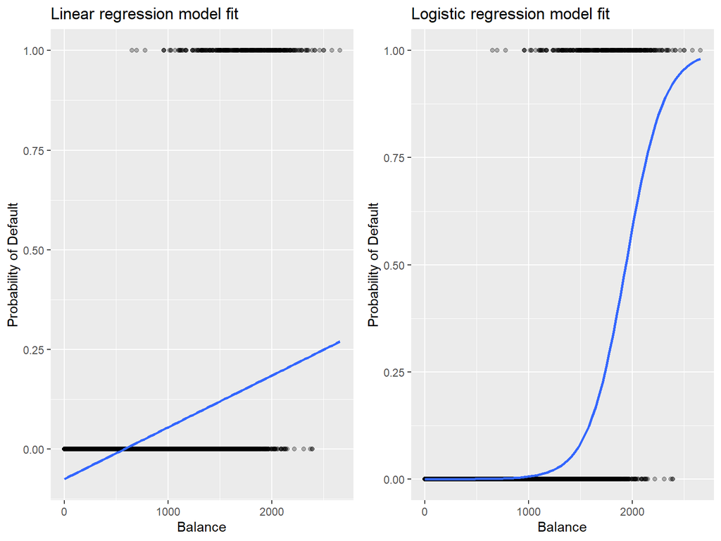

# Bibliografia

– *Applied Linear Statistical Models*, Michael H. Kutner, Christopher J. Nachtsheim, John Neter, William Li, 2005;

– Prezentacja *Introduction to Generalized Linear Models*, Heather Turner, 2008;

– *Hands-on Machine Learning with R*, Bradley Boehmke, Brandon Greenwell, 2020;

– *A Practitioner’s Guide to Generalized Linear Models*, Duncan Anderson, Sholom Feldblum, Claudine Modlin, Doris Schirmacher, Ernesto Schirmacher, Neeza Thandi, 2007;

– Kurs *Statistics for Applications*, Philippe Rigollet MIT, 2016, https://www.youtube.com/watch?v=X-ix97pw0xY;

Dyskusje na forach:

– https://stats.stackexchange.com/questions/40876/what-is-the-difference-between-a-link-function-and-a-canonical-link-function

– https://stats.stackexchange.com/questions/20523/difference-between-logit-and-probit-models#30909